# Data analysis and visualization using R

## Plot decoration

- By passing arguments to `plot()` you can modify or add many features of your plot
- Basic decoration includes
  - adjusting markers (`pch = 19`, `col = "blue"`)
  - adding connector lines (`type = "b"`)
  - adding axis labels and title (`xlab = "Time (hours)"`, `ylab = "Systemic response"`, `main = "Systemic response to agent X"`)
  - adjusting axis limits (`xlim = c(0, 8)`)

## Plot decoration

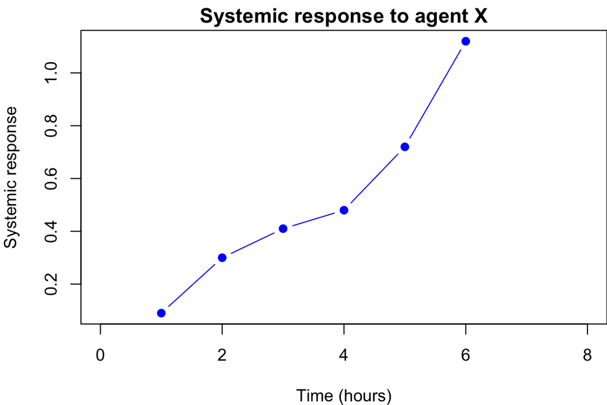

```r
plot(x = time, y = response, pch = 19, type = "b", xlim = c(0, 8),
     xlab = "Time (hours)", ylab = "Systemic response",
     main = "Systemic response to agent X", col = "blue")
```

## Barplots

- Barplots can be generated in two ways
  - By passing a factor to plot() - simple of level frequencies
  - By using barplot()

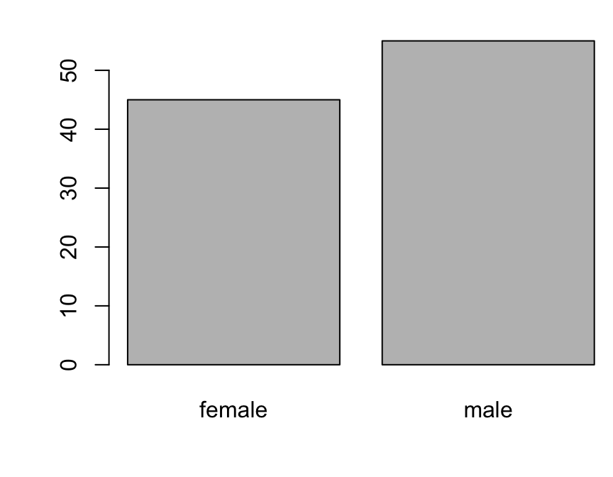

```r
persons <- as.factor(sample(c("male", "female"), size = 100, replace = T))
plot(persons)
```

## `barplot()`

- `barplot()` can be called with a vector of heights (frequencies) or a table() object

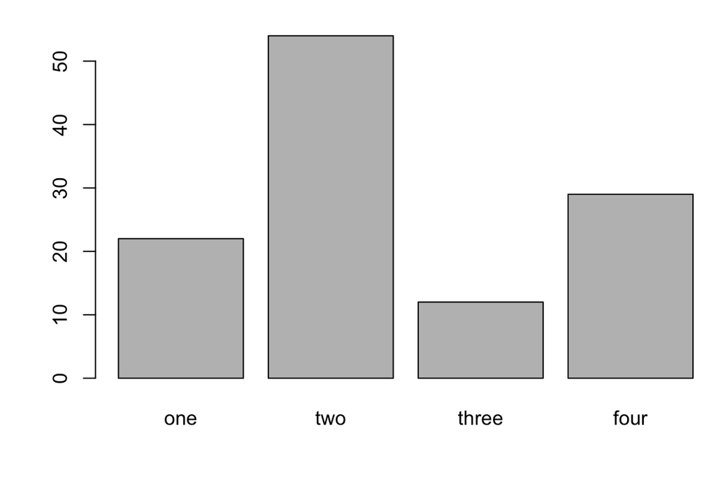

```r
frequencies <- c(22, 54, 12, 29)
barplot(frequencies, names = c("one", "two", "three", "four"))
```

## `barplot()` with a table object

```r
table(persons)
```

```
persons
female   male
    45     55
```

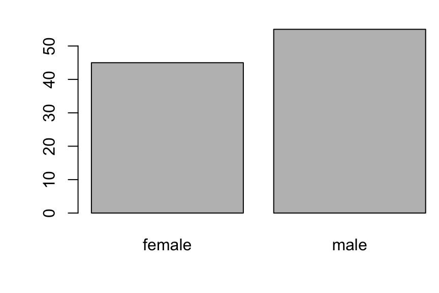

```r
barplot(table(persons))
```

## Histograms

Histograms help you visualise the distribution of your data

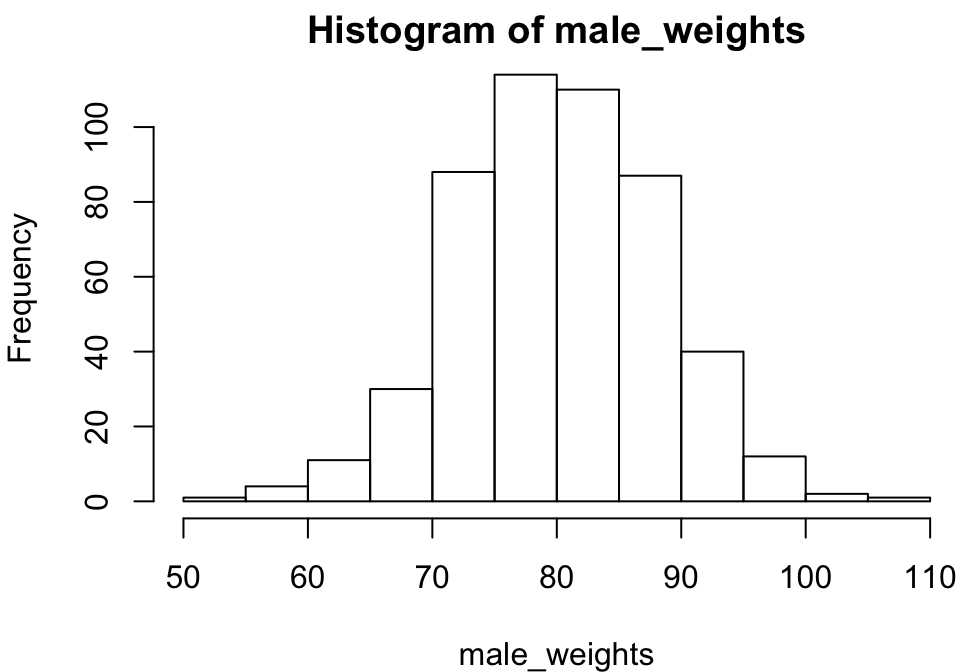

```r
male_weights <- c(rnorm(500, 80, 8)) ## create 500 random numbers around 80
hist(male_weights)
```

## Histograms (2)

Using the `breaks` argument, you can adjust the bin width. Always explore this option when creating histograms!

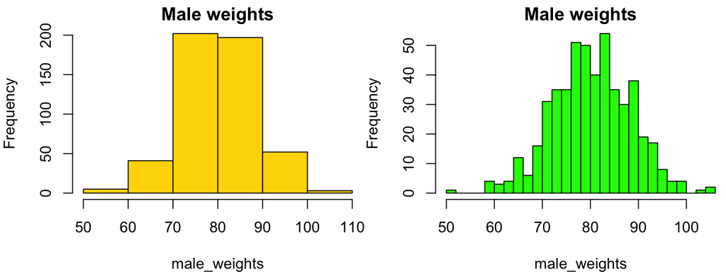

```r
par(mfrow = c(1, 2)) # make 2 plots to sit side by side
hist(male_weights, breaks = 5, col = "gold", main = "Male weights")
hist(male_weights, breaks = 25, col = "green", main = "Male weights")
```

## Boxplots

This is the last of the basic plot types. A boxplot is a visual representation of the *5-number summary* of a variable.

```r
persons <- rep(c("male", "female"), each = 100)
weights <- c(rnorm(100, 80, 6), rnorm(100, 75, 8))
#print 6-number summary (5-number + mean)
summary(weights[persons == "female"])
```

```
   Min. 1st Qu.  Median    Mean 3rd Qu.    Max.
  55.34   67.38   73.31   73.32   79.22   96.76
```

## Boxplots (2)

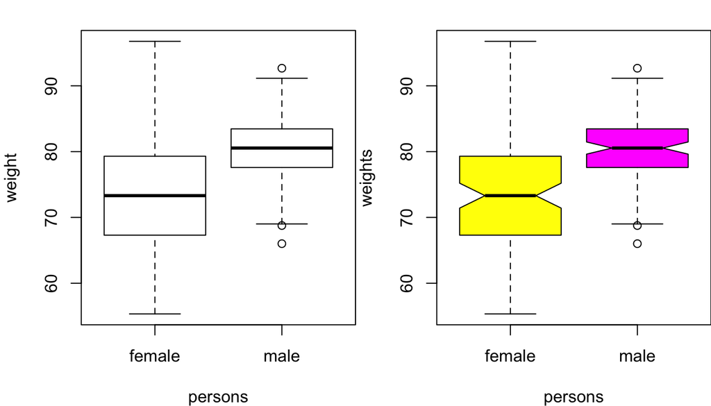

```r
par(mfrow = c(1, 2)) # make 2 plots to sit side by side
# create boxplots of weights depending on sex
boxplot(weights ~ persons, ylab = "weight")
boxplot(weights ~ persons, notch = TRUE, col = c("yellow", "magenta"))
```

## Part 6: Some ground rules

## Plotting rules

Plots should always have these decorations

- A descriptive title
- Axis labels indicating measurement type and its units
- If multiple data series are plotted: a legend

*For the sake of space saving, I will not always adhere to these rules in my presentations*

## Coding style rules

- Names of variables start with a lower-case letter
- Words are separated using underscores
- Be descriptive with names
- Function names are verbs
- Write all code and comments in English
- Preferentially use one statement per line
- Use spaces on both sides of ALL operators
- Use a space after a comma
- Indent code blocks -with {}- with 4 or 2 spaces, but be consistent

Follow Hadleys’ style guide http://adv-r.had.co.nz/Style.html

## Wrap-up of the basics

- help on function: `help(function)`
- or `?function`
- autocomplete/suggestions in RStudio: `tab` key
- help (in Rstudio): F1
- installing a library that is not in the core packages: `install.packages("ggplot2"")`
- loading a library that is not in the core packages: `library(ggplot2)`
- remove variable(s): `rm(x, y, z, myData)`